# Creating an Event System

As of now, we have a basic level. There’s only one *Wave* with a fixed amount of *Enemies*, and there’s no progression.

We’re going to create a system that plays a list of events in order. For instance, we want to create a list of *Waves* that should spawn one after the other as the player defeats them.

We can make changes to properties through the *Inspector* with Godot’s animation system. Then we can save these changes as animations. We’ll serialize object states and load them during run-time by playing the animations.

Let’s turn our *AnimationPlayer* into an *EventsPlayer*. Rename it to *EventsPlayer* and attach a new script to it. You can save the script as `res://Levels/EventsPlayer.gd`.

This events system indexes the *AnimationPlayer*’s list of animations and plays them in order. As *AnimationPlayers* index their animations by their name, we’ll use indexing characters to name our events. This allows us to control the order of our *Level*’s events.

In the *EventsPlayer* script, let’s export a variable. It represents the current event the *EventsPlayer* will play. It starts with a value of `0` by default. This means we’ll start with the first animation on the list.

```
extends AnimationPlayer

export var current_event = 0

func play_event(event_index := current_event) -> void:
```

Inside the `play_event()` method, we need to check if it has reached the end of the events list. We gather the list of animations using the *AnimationPlayer* `get_animation_list()` method and assign it to the `events_list` variable.

We can then count how many animations we have and we check if the `event_index` is greater or equal to the amount of animations in the list. If so, we return from the `play_event()` to stop further execution.

If we have enough events to match the current `event_index`, we can play the event.

```
func play_event(event_index := current_event) -> void:
    # Stores the list of animations and checks if the event_index is within its
    # range
    var events_list: Array = get_animation_list()
    var animation_count := events_list.size()
    if event_index >= animation_count:
        return

    # Plays the animation at the `event_index` position in the `events_list`
    play(events_list[event_index])
```

We’ve indexed our events so that we can automate the process of progressing through them. We’ll create the `play_current_event()` which plays the `current_event` and increases it by `1`. It will play the next event the next time it’s called.

```
func play_current_event() -> void:
    play_event()
    current_event += 1
```

## Creating new events

We need to create something to instance *Waves* dynamically because we want to change the current *Wave* as the player progresses. Otherwise, they would be facing the same horde of enemies over and over again.

We can create a *Spawner* class that handles the instancing of game entities in the game world.

[figure not shown]

[figure not shown]

`PackedScene`. This is what we did with the *Weapon* and the *Bullets*.

Let’s add a *Position2D* as a child of the *Level* and rename it as *WaveSpawner2D*. Attach a script to it and save it as `res://Levels/WaveSpawner2D.gd`.

[figure not shown]

`PackedScene` to allow us to change the `spawn_scene` through the *Inspector*. This is going to be the object the spawner spawns.

With this property available through the *Inspector*, we can change it using animations and spawn different *Waves* of enemies. Each *EventsPlayer* animation changes the `spawn_scene` to a new *Wave*.

We’ll create a `spawn()` method to spawn instances of the `spawn_scene`. This is a public method because we’ll call it through the *Level* later on. The *Level* dictates when *Waves* should appear which is why uses the *WaveSpawner2D*.

[figure not shown]

[figure not shown]

[figure not shown]

`Node` objects.

```
# Spawns enemy waves.
class_name WaveSpawner2D
extends Position2D

export var spawn_scene: PackedScene


func spawn() -> Node2D:
    var spawn: Node2D = spawn_scene.instance()

    add_child(spawn)
```

We flag each `spawn` instance as top level to prevent them inheriting transform effects from *WaveSpawner2D*. We set their positions manually instead.

```
func spawn() -> Node2D:
    # ...

    # Prevents the spawner's transform from affecting the spawn's
    spawn.set_as_toplevel(true)

    # Reposition the spawn in the game's world
    spawn.global_position = global_position
```

We’ll create a `spawned` signal and emit it to notify other classes that the *WaveSpawner2D* spawned something.

```
class_name WaveSpawner2D
extends Position2D

signal spawned(spawn)

export var spawn_scene: PackedScene

func spawn() -> Node2D:
    # ...
    emit_signal("spawned", spawn)
```

Let’s return the `spawn` instance at the end of the method. This will provide a reference to client classes if they need to access the `spawn`.

```
func spawn() -> Node2D:
    # ...
    return spawn
```

## Code so far

Let’s take a look at the code of the classes we’ve created so far to ensure that our tests will match.

`EventsPlayer.gd`

```
extends AnimationPlayer

export var current_event = 0

func play_event(event_index := current_event) -> void:
    var events_list: Array = get_animation_list()
    var animation_count := events_list.size()
    if event_index >= animation_count:
        return
    play(events_list[event_index])


func play_current_event() -> void:
    play_event()
    current_event += 1
```

`WaveSpawner2D.gd`

```
# Spawns enemy waves.
class_name WaveSpawner2D
extends Position2D

signal spawned(spawn)

export var spawn_scene: PackedScene


func spawn() -> Node2D:
    var spawn: Node2D = spawn_scene.instance()

    add_child(spawn)
    spawn.set_as_toplevel(true)
    spawn.global_position = global_position

    emit_signal("spawned", spawn)
    return spawn
```

## Testing the events system

Let’s create two different *Waves* to test this system. Delete the current *Wave* we have in the *Level* and create a new scene.

As the root node of this new scene, create a *Wave* and add some *Enemies* as its children. Three should be enough.

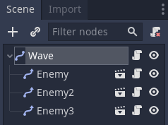

Draw a straight path so we can see the *Enemies* move and disappear.

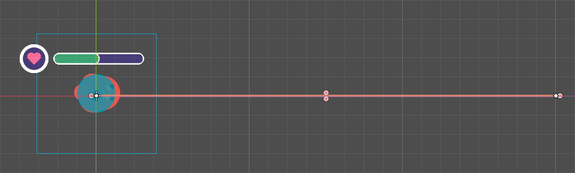

Save this *Wave* as `res://Levels/Waves/Wave1.tscn`.

Create another *Wave* scene and add a different set of *Enemies* to increase the difficulty. Five should do the trick. Again, create a straight path so we can see these *Enemies* moving. Save it as `res://Levels/Waves/Wave2.tscn`.

Back to the *Level* scene now.

In the *EventsPlayer* let’s create two animations. Remember, *AnimationPlayers* index their animation list in alphabetical order. We’ll prefix indexing characters to our animation names to follow `00.first-wave`, `01.second-wave` and so on.

Create the `00.first-wave` animation.

Drag the `res://Levels/Waves/Wave1.tscn` to the *WaveSpawner2D > Spawn Scene* property. Then, add a new *Property Track* key using the key icon at the right.

[figure not shown]

As an alternative, you could add a *Property Track* to the animation and select the *WaveSpawner2D* before choosing the `spawn_scene` property.

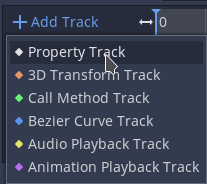

After that, right click on the animation’s timeline and add a key to `spawn_scene` current value.

Create the `01.second-wave` animation. Drag the `res://Levels/Waves/Wave2.tscn` to the *WaveSpawner2D > Spawn Scene* slot and repeat the process of adding a new key to the `spawn_scene` current value.

At the end of each animation, let’s add a *Call Method Track*. Here we’ll add a key to call the *WaveSpawner2D*’s `spawn()` method. This is a test track, we must remove it after we finish with our tests.

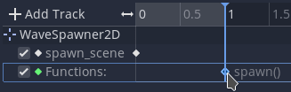

Let’s connect the *WaveSpawner2D*’s `spawned` method to the *EventsPlayer* `_on_WaveSpawner2D_spawned()` callback. This is also a test measure, we must undo it after we finish with our tests.

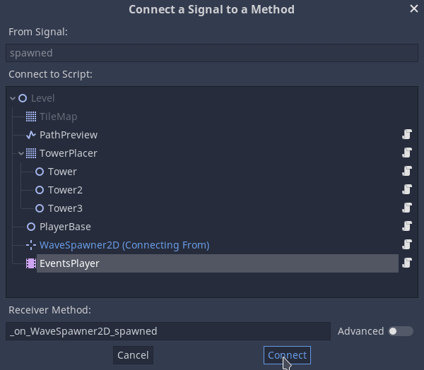

*Waves* use the `start()` method to make *Enemies* move so let’s call the `spawn.start()` method on the `spawn` object we receive in this callback.

Then we wait for the *Wave* to emit its `finished` signal using the `yield` keyword.

When the *Wave* finishes, we play the next event on the list using the `play_current_event()` method.

```
# This is a test callback, disconnect the signal from the WaveSpawner2D after
# testing
# Begin of test lines
func _on_WaveSpawner2D_spawned(spawn: Wave) -> void:
    spawn.start()
    yield(spawn, "finished")
    play_current_event()
# End of test lines
```

Let’s kickoff the events in the *EventsPlayer*’s `_ready()` callback. Again, this is a test block so make sure to delete it after testing.

```
# This is a test call to kickoff the first event and see how the event system
# behaves.
# Delete this block after the tests.
# Begin of test lines
func _ready() -> void:
    play_current_event()

# End of test lines
```

With that, we should see our *Waves* appear. *Enemies* walk towards the end of the *Wave*’s path, disappear and the next *Wave* starts. When the second *Wave* finishes nothing should happen and our test is over.

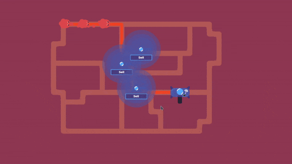